# Week_5

## Popular R Programming Packages for Analytics (Cont.)

### Twitter Case Study

In this session, we will retrieve and analyze text data from a popular social network site, Twitter, by using “rtweet” package. This session doesn’t intend to go deep in natural language processing, instead, introduce a high level R programming implemetation on text analytics. I suggest you do further reading from [this book](https://www.tidytextmining.com/) if you are interested in this topic.

[figure not shown]

Twitter & R

[image source](http://www.shakti-singh.com/blog/how-to-use-twitter-api-with-php/)

#### rtweet with Twitter API

“rtweet” is one of the most popular packages to use and analyze Twitter data. However, first you need to be authorized to pull from the twitter API. To get your API credentials, simply follow the steps [documented here](https://cran.r-project.org/web/packages/rtweet/vignettes/auth.html). The process is pretty seamless and once you obtain your keys/credentials, rtweet will remember you next time when you decide use Twitter data.

1.First of all, we will need to install and use the following packages in our environment:

```r
install.packages("rtweet")
install.packages("tidytext")
install.packages("dplyr")
install.packages("stringr")
require(devtools)
install_github("lchiffon/wordcloud2")

library(tidytext)
library(dplyr)
library(stringr)
library(rtweet)
library(wordcloud2)
```

2.Establish your Token and Credentials Execute the following code to to establish your token. As per the rtweet reference article, the create_token() function automatically saves your token as an environment variable for future use.

```r
create_token(
  app = "PLACE YOUR APP NAME HERE",
  consumer_key = "PLACE YOUR CONSUMER KEY HERE",
  consumer_secret = "PLACE YOUR CONSUMER SECRET HERE")
# i.e. Mine looks like this
# app = "Programming for Analytics",
# consumer_key = "mze3d9Ijfq3P39okYUDipT7sQ",
# consumer_secret = "YwCgVtgW8dWzSD74EYMat2dVuBBNun8WW67V94LJTAyjgy8RFo ")
```

3.Retrieve Tweets Use the search_tweets() function to grab 1000 tweets with the hashtag of your choice. I chose to look into #Analytics because I guess we all love that term. We will then look at the data collected from the tweets via the head() and dim() commands. We will then use the unnest() command to transform the data to have only one word per row. Next, we remove common words such as “the”, “it” etc via the stop_words data set. Finally, we will filter out a custom set of words of our choice. Also [refer](https://rtweet.info/articles/intro.html) for rtweet details.

```r
#Grab tweets - note: reduce to 500 if it's slow
hmt <- search_tweets(
  "#Analytics", n = 1000, include_rts = FALSE
)
```

```r
#Look at tweets
head(analytics)
dim(analytics)
analytics$text
```

[output not shown]

```r
#Unnest the words - code via Tidy Text, recall the pipe usage %>%
analyticsTable <- analytics %>%
  unnest_tokens(word, text)
```

```r
#remove stop words - aka typically very common words such as "the", "of" etc
data(stop_words)
analyticsTable <- analyticsTable %>%
  anti_join(stop_words)
```

```r
#perform a word count
analyticsTable <- analyticsTable %>%
  count(word, sort = TRUE)
```

```r
#Remove other nonsense words of your choice
analyticsTable <-analyticsTable %>%
  filter(!word %in% c('t.co', 'https',
                       "it's",
                      'day', 'month', 'week','hum','de','el','le','la','en' ))
```

4.Create a World Cloud Use the wordcloud2() function out of the box to create a wordcloud on the #Analytics tweets.

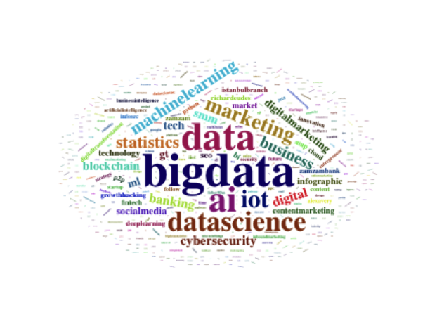

#Analytics

```r
wordcloud2(analyticsTable, size=0.8)
```

5.Create Customized Word Clouds Plotting a word cloud is good, but customizing it with our preference is better. We need a color palette that suits the show and we would like a more suitable shape. To do this we create a list of hex codes for our redPalette. We then use some symbols within our context of our choice to create the word cloud shape by referencing local files. Finally we create the word cloud via the wordcloud2() function and we set the shape with the figPath attribute.

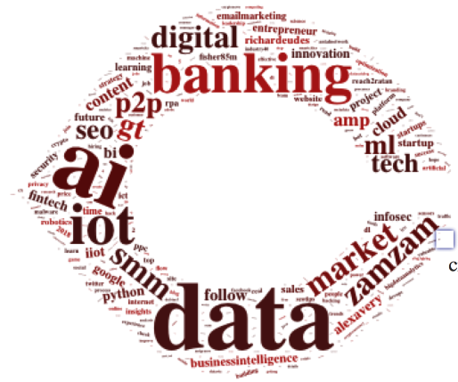

University of Chicago Athletics

[figure not shown]

#Apple

[figure not shown]

#Analytics for broken hearts

```r
#Create Palette
redPalette <- c("#5c1010", "#6f0000", "#560d0d", "#c30101", "#940000")
redPalette

## the symbols can easily be retrieved fromn local directory or you can use download.file() function to scrape a symbol from web as download.file(url, "name.jpg")
graham <- "Uchicago_athletics.png"
apple<-"apple.jpg"
heart<-"heartt.png"
#plots
wordcloud2(analyticsTable, size=1.6, figPath = graham, color=rep_len( redPalette, nrow(analyticsTable) ) )
wordcloud2(analyticsTable, size=3.6, figPath = apple, color=rep_len( redPalette, nrow(analyticsTable) ) )
wordcloud2(analyticsTable, size=1.6, figPath = heart, color="#B20000")
```